# R Notebook

```r
library(readr)
d.df <- read_csv("2019VAERSDATA.csv")
```

```
28 parsing failures.
 row          col           expected actual                file
2093 BIRTH_DEFECT 1/0/T/F/TRUE/FALSE      Y '2019VAERSDATA.csv'
3135 BIRTH_DEFECT 1/0/T/F/TRUE/FALSE      Y '2019VAERSDATA.csv'
3159 BIRTH_DEFECT 1/0/T/F/TRUE/FALSE      Y '2019VAERSDATA.csv'
4316 BIRTH_DEFECT 1/0/T/F/TRUE/FALSE      Y '2019VAERSDATA.csv'
4730 BIRTH_DEFECT 1/0/T/F/TRUE/FALSE      Y '2019VAERSDATA.csv'
.... ............ .................. ...... ...................
See problems(...) for more details.
```

```r
install.packages("Hmisc")
```

```
Error in install.packages : ERROR: failed to lock directory ‘C:\Users\CaseMGR\OneDrive\Documents\R\win-library\4.0’ for modifying
Try removing ‘C:\Users\CaseMGR\OneDrive\Documents\R\win-library\4.0/00LOCK’
```

```r
library(Hmisc)
install.packages ("ggplot2")
```

```
Error in install.packages : Updating loaded packages
```

```r
library ("ggplot2")
```

First I upload the VAERS data file that is being used and installed all necessary packages

```r
data <- d.df[,c("VAERS_ID","STATE","AGE_YRS", "SEX", "NUMDAYS")]
head(data)
```

| VAERS_ID | STATE | AGE_YRS | SEX | NUMDAYS |
| --- | --- | --- | --- | --- |
| 794156 | NA | 69 | F | 1 |
| 794157 | IL | 68 | F | 1 |
| 794158 | MA | 62 | F | 1 |
| 794159 | UT | 5 | M | 1 |
| 794160 | TX | 79 | F | 0 |
| 794161 | MN | 57 | F | 1 |

Created a subset of the data with only the columns corresponding to the ID, state, age, sex, and number of days hospitilized and displayed the head of the data.

```r
summary(data)
```

```
    VAERS_ID         STATE              AGE_YRS          SEX
 Min.   :794156   Length:48454       Min.   :  0.0   Length:48454
 1st Qu.:809939   Class :character   1st Qu.: 17.0   Class :character
 Median :825494   Mode  :character   Median : 57.0   Mode  :character
 Mean   :825041                      Mean   : 45.9
 3rd Qu.:840026                      3rd Qu.: 68.0
 Max.   :863680                      Max.   :113.0
                                     NA's   :11746
    NUMDAYS
 Min.   :    0.00
 1st Qu.:    0.00
 Median :    0.00
 Mean   :   23.54
 3rd Qu.:    1.00
 Max.   :32872.00
 NA's   :11520
```

```r
range(data$AGE_YRS, finite= TRUE)
```

```
[1]   0 113
```

The age range is from zero to one hundred and thirteen.

```r
data[order(-data$AGE_YRS),]
```

| VAERS_ID | STATE | AGE_YRS | SEX | NUMDAYS |
| --- | --- | --- | --- | --- |
| 854968 | IL | 113 | F | NA |
| 805825 | IA | 111 | F | NA |
| 827038 | AZ | 103 | F | 1 |
| 843026 | NA | 102 | F | NA |
| 798122 | CA | 100 | F | 0 |
| 815589 | NA | 100 | F | NA |
| 839583 | NY | 99 | F | 3 |
| 833489 | KS | 98 | F | 1 |
| 839761 | CA | 98 | F | 0 |
| 823169 | NJ | 97 | F | NA |

[output cut: 990 more lines]

Listed the data in descending order by age

```r
range(data$NUMDAYS, finite= TRUE)
```

```
[1]     0 32872
```

```r
data[order(-data$NUMDAYS),]
```

| VAERS_ID | STATE | AGE_YRS | SEX | NUMDAYS |
| --- | --- | --- | --- | --- |
| 845434 | FL | 90.00 | F | 32872 |
| 826503 | NY | 89.00 | F | 32547 |
| 841581 | IL | 86.00 | M | 31422 |
| 819826 | GA | NA | F | 28410 |
| 813186 | CT | 74.00 | M | 27394 |
| 823372 | VA | 73.00 | F | 26826 |
| 834995 | FL | 68.00 | F | 25211 |
| 824119 | VA | 67.00 | F | 24472 |
| 819197 | CA | 67.00 | M | 24471 |
| 834936 | OR | 66.00 | F | 24364 |

[output cut: 990 more lines]

```r
S <-table(d.df$SEX)
S
```

```
    F     M     U
28076 13735  6643
```

From the table I know the frequency of each gender on the list. Females = 28076 Male= 13735 Unknown= 6643

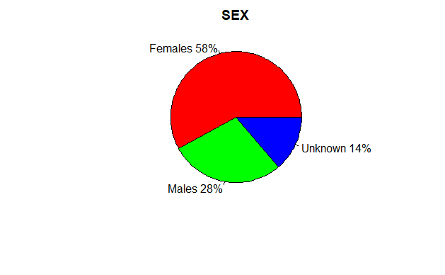

```r
slices <- c(28076, 13735,6643)
lbls <- c("Females", "Males", "Unknown")
pct <- round(slices/sum(slices)*100)
lbls <- paste(lbls, pct) # add percents to labels
lbls <- paste(lbls,"%",sep="") # ad % to labels
pie(slices,labels = lbls, col=rainbow(length(lbls)),
    main="SEX")
```

The pie chart shows the gender that appear the most on the VAERs system is females

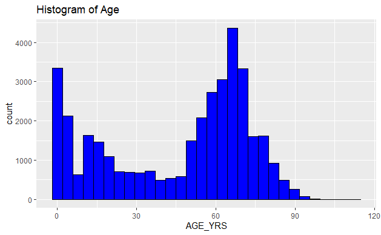

```r
library(ggplot2)
ggplot() + geom_histogram(data= d.df, aes(x=AGE_YRS),fill="blue",
                          color="black")+ggtitle("Histogram of Age")
```

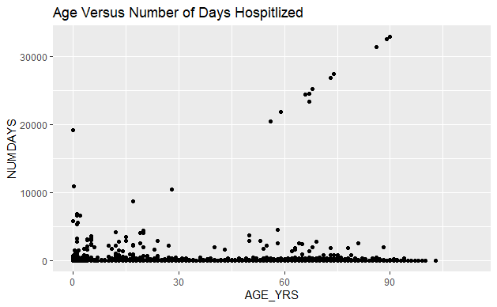

```r
library(ggplot2)
ggplot(d.df,aes(x=AGE_YRS, y= NUMDAYS ))+geom_point() +ggtitle("Age Versus Number of Days Hospitlized")
```

Most of the data is concentrated at the bottom part of the plot indicating that most of people on the VAERS list did not spend a lot of time at the hospital.

```r
IQR(d.df$NUMDAYS,na.rm = TRUE)
```

```
[1] 1
```

Most of the people on the VAERs list were not hospitalized regardless of age. The IQ range is 1 considering all of the people on listed that were hospitalized.

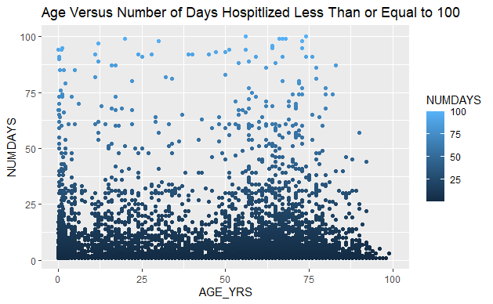

Took a closer look at previous scatter plot. This plot only shows data from people who at least spent 1 day in the hospital but no more than 100 days. Of the people admitted to the hospital majority of the data across all ages is concentrated at the bottom of the graph. This indicates that there is not a correlation between age and the number of days in hospital.

| state | Freq |
| --- | --- |
| AK | 165 |
| AL | 437 |
| AR | 232 |
| AZ | 819 |
| CA | 3240 |
| CO | 760 |
| CT | 442 |
| DC | 73 |
| DE | 130 |
| FL | 1973 |

[output cut: 47 more lines]

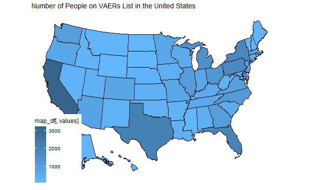

|  | state | Freq |
| --- | --- | --- |
| 5 | CA | 3240 |
| 49 | TX | 2117 |
| 10 | FL | 1973 |
| 38 | NY | 1860 |
| 42 | PA | 1749 |
| 26 | MI | 1466 |
| 39 | OH | 1271 |
| 31 | NC | 1162 |
| 17 | IL | 1029 |
| 22 | MA | 989 |

[output cut: 47 more lines]

Table of frequency of a state on the VAERs list